# Analysis of loyal customers

In this notebook, basic information about “loyal” customers is analyzed. A customer is loyal if he returned to the shop after first order and bought something again. First, some data cleaning and preparation is needed:

```r
library(readr)
library(tidyverse)
library("leaflet")
library(psych)
library(lubridate)
library(cluster)
library(factoextra)

# load datasets
orders <- read_csv("data/olist_orders_dataset.csv")
customers <- read_csv("data/olist_customers_dataset.csv")
geolocation <- read_csv("data/olist_geolocation_dataset.csv")
order_items <- read_csv("data/olist_order_items_dataset.csv")
order_payments <- read_csv("data/olist_order_payments_dataset.csv")
order_reviews <- read_csv("data/olist_order_reviews_dataset.csv")
products <- read_csv("data/olist_products_dataset.csv")
sellers <- read_csv("data/olist_sellers_dataset.csv")
product_translation <- read_csv("data/product_category_name_translation.csv")


# for each order there can be multiple payments (installments). Aggregation to an order
order_payments %>%
  group_by(order_id) %>%
  summarise(payment_value = sum(payment_value)) -> order_payments_agg

# obtain the newest rating for each order
order_reviews %>%
  group_by(order_id) %>%
  filter(review_creation_date == max(review_creation_date)) %>%
  select(order_id, review_score) -> ratings

# main join of relevant tables
orders %>%
  select(order_id,
         customer_id,
         order_purchase_timestamp) %>%
  left_join(order_payments_agg, by = c('order_id'='order_id')) %>%
  left_join(customers %>% mutate(zip=str_sub(customer_zip_code_prefix, 1, 1)) %>%
              select(customer_id, customer_unique_id,zip, customer_zip_code_prefix)) %>%
  select(5,1,3,4,6,7) %>%
  arrange(customer_unique_id, order_purchase_timestamp) %>%
  group_by(customer_unique_id) %>%
  mutate(order_no=row_number()) %>%
  ungroup() %>%
  left_join(ratings) -> orders_master
```

Checking number of items bought by each customer:

```r
orders_master %>%
  select(order_no) %>%
  group_by(order_no)%>%
  tally()
```

```
## # A tibble: 17 x 2
##    order_no     n
##       <int> <int>
##  1        1 96180
##  2        2  3060
##  3        3   262
##  4        4    49
##  5        5    19
##  6        6    11
##  7        7     5
##  8        8     2
##  9        9     2
## 10       10     1
## 11       11     1
## 12       12     1
## 13       13     1
## 14       14     1
## 15       15     1
## 16       16     1
## 17       17     1
```

Majority of the customers have bought only one time. Let’s check general profitability of the customer depending on number of his orders:

```r
orders_master %>%
  group_by(customer_unique_id) %>%
  summarise(
    no_orders = max(order_no),
    profit = sum(payment_value)
  ) %>%
  group_by(no_orders) %>%
  summarise(avg_profit=mean(profit, na.rm = T))
```

```
## # A tibble: 9 x 2
##   no_orders avg_profit
##       <int>      <dbl>
## 1         1       162.
## 2         2       300.
## 3         3       491.
## 4         4       793.
## 5         5       760.
## 6         6       705.
## 7         7       947.
## 8         9      1173.
## 9        17       928.
```

This is quite obvious, but customers who have bought more times also are more profitable. This means that customer retention is potentially very rewarding for the company.

We can check the behaviour of customers that bought at least one time, to see if it is possible to predict, which of the one-timers may be potentially interested in buying second time.

In other words, we can check the behaviour of loyal customer in the past, that is during their first purchase.

Percentage of people that bought x times that also bought x+1 times:

```r
orders_master %>%
  select(order_no) %>%
  group_by(order_no)%>%
  tally() %>%
  mutate(n2 = n/lag(n))
```

```
## # A tibble: 17 x 3
##    order_no     n      n2
##       <int> <int>   <dbl>
##  1        1 96180 NA
##  2        2  3060  0.0318
##  3        3   262  0.0856
##  4        4    49  0.187
##  5        5    19  0.388
##  6        6    11  0.579
##  7        7     5  0.455
##  8        8     2  0.4
##  9        9     2  1
## 10       10     1  0.5
## 11       11     1  1
## 12       12     1  1
## 13       13     1  1
## 14       14     1  1
## 15       15     1  1
## 16       16     1  1
## 17       17     1  1
```

There is 3% chance that people who bought one time will also buy second time. But for placing the third order when a customer made second order is 8.5%. So, after making second buy the chances of longer loyalty grow. This proves that making the customer place second order is the hardest part in retention of the client.

Later data processing: select first order, with indication if particular customer bought also next time.

```r
orders_master %>%
  filter(order_no>1) %>%
  distinct(customer_unique_id) %>%
  .$customer_unique_id -> loyal_customers_ids

orders_master %>%
  filter(order_no==1) %>%
  select(-order_no) %>%
  mutate(if_second_order = ifelse(customer_unique_id %in% loyal_customers_ids,
                                  '1',
                                  '0'
                                  )) -> first_orders
```

Descriptive statistics for first order:

Distribution of first order value with indication if the customer has also placed second order:

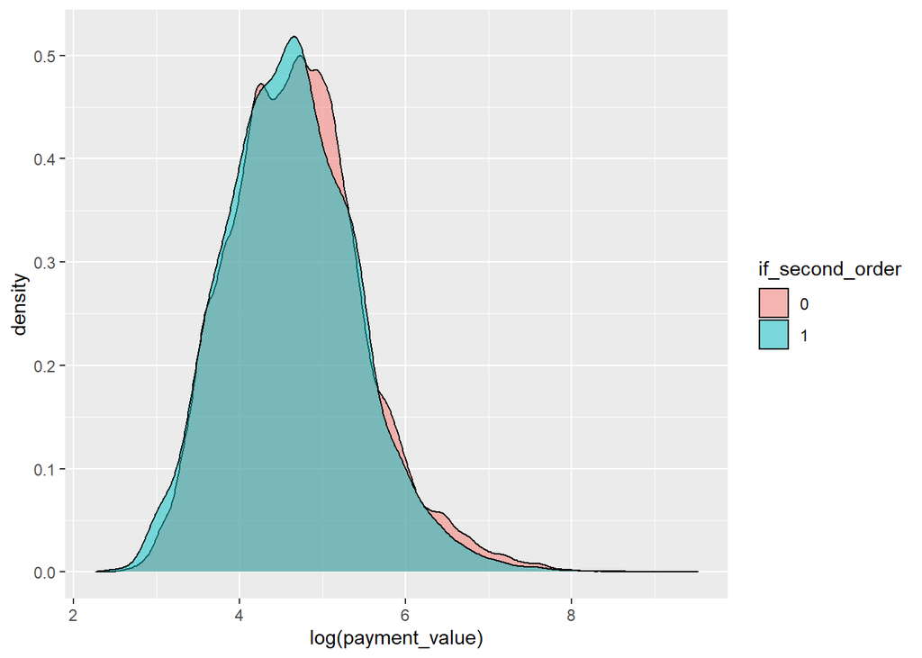

```r
first_orders %>%
  ggplot(aes(x = log(payment_value), fill=if_second_order)) +
  geom_density(alpha=0.5)
```

No visible difference between these.

Distribution of review score placed after purchase - hypothesis is that low values of review don’t lead to future buys - customer is discouraged to the shop.

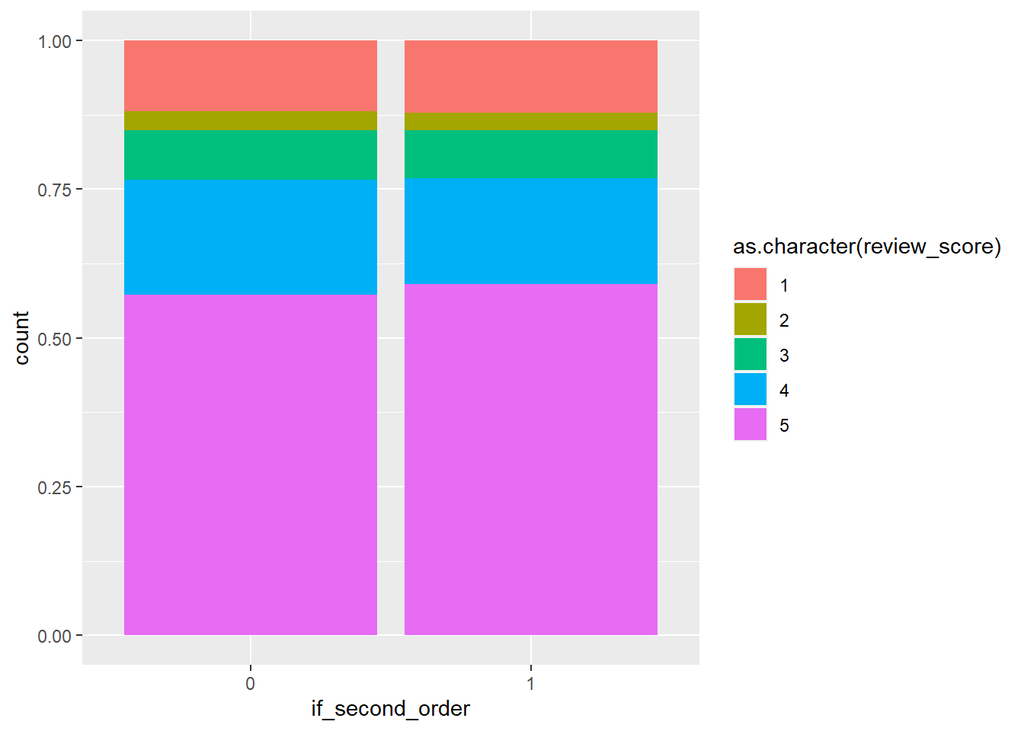

```r
first_orders %>%
  ggplot(aes(fill = as.character(review_score), x=if_second_order)) +
  geom_bar(stat='count', position='fill')
```

No difference - this is somehow strange. If the reception was bad for the first time, why did the customer decide to buy again? This can also mean that customer loyalty is not so important in e-commerce sector!

Test average time between buys:

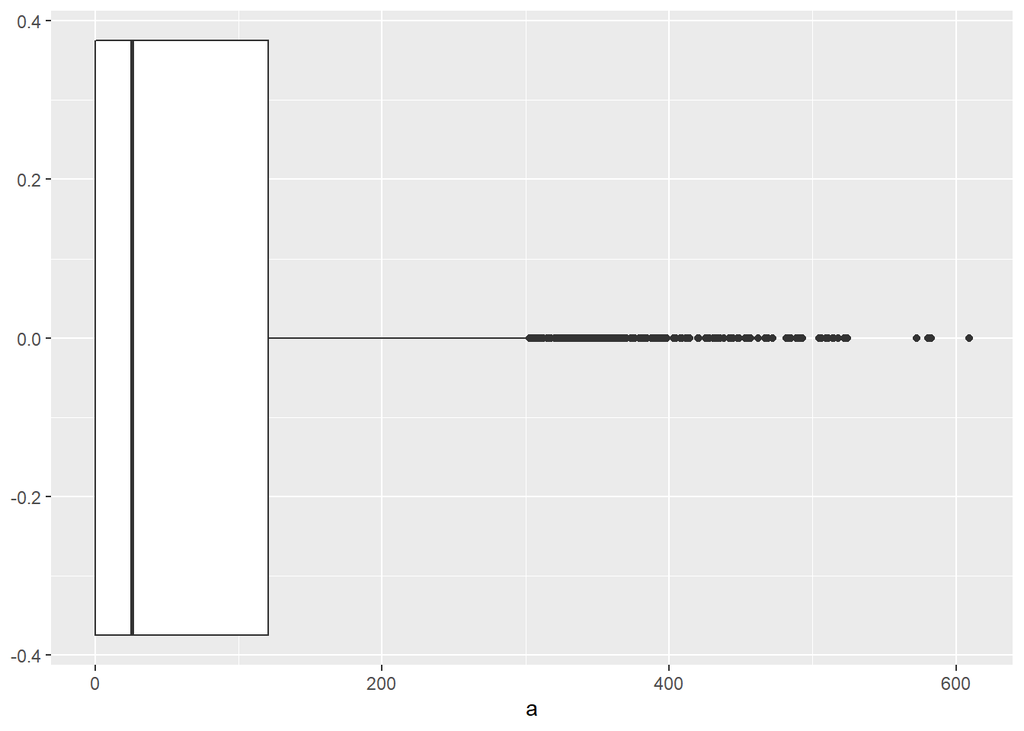

```r
orders_master %>%
  filter(customer_unique_id %in% loyal_customers_ids) %>%
  arrange(customer_unique_id) %>%
  group_by(customer_unique_id) %>%
  arrange(order_no) %>%
  mutate(previous_order_time = lag(order_purchase_timestamp)) %>%
  filter(!is.na(previous_order_time))%>%
  ungroup() %>%
  arrange(customer_unique_id) %>%
  mutate(a = order_purchase_timestamp-previous_order_time) -> time_since_last

units(time_since_last$a) <- 'days'

time_since_last %>%
  filter(order_no == 2) %>%
  ggplot(aes(x=a)) +
  geom_boxplot()
```

```r
options(scipen = 11111111)
time_since_last %>%
  filter(order_no == 2) %>%
  select(a) %>%
  .$a %>%
  quantile(c(0.25, 0.5, 0.63, 0.7, 0.75))
```

```
## Time differences in days
##             25%             50%             63%             70%             75%
##   0.00003472222  25.54140046296  61.58544016204  93.18647569444 120.89765914352
```

- 50% of second orders are placed within 25 days from first buy
- 63% are placed within 2 months
- 70% are placed within 3 months
- 75% are placed within 4 months

This proves that ‘leads get colder’ - the longer the time from first order, the less likely it is to make customer place second order

Now let’s check if location of the customer influences if he will become loyal customer. zip code present in the dataset has 5 digits, and each consecutive digit gives another level of deaggregation. First, check the biggest level of aggregation - 10 ‘macroregions’:

```r
first_orders %>%
  group_by(zip, if_second_order) %>%
  tally() %>%
  ungroup() %>%
  pivot_wider(values_from = n,names_from=if_second_order, names_prefix='if_loyal') %>%
  mutate(perc_second_purchase= if_loyal1/(if_loyal0+if_loyal1))
```

```
## # A tibble: 10 x 4
##    zip   if_loyal0 if_loyal1 perc_second_purchase
##    <chr>     <int>     <int>                <dbl>
##  1 0         22363       792               0.0342
##  2 1         16640       534               0.0311
##  3 2         13864       490               0.0341
##  4 3         10916       354               0.0314
##  5 4          3513       106               0.0293
##  6 5          2925        78               0.0260
##  7 6          3716        83               0.0218
##  8 7          5911       202               0.0330
##  9 8          8167       247               0.0294
## 10 9          5110       169               0.0320
```

There is very small difference in percentages between regions. Now, let’s try to dig deeper into second level of aggregation:

```r
first_orders %>%
  mutate(zip = str_sub(customer_zip_code_prefix, 1,2)) %>%
  group_by(zip, if_second_order) %>%
  tally() %>%
  ungroup() %>%
  pivot_wider(values_from = n,names_from=if_second_order, names_prefix='if_loyal') %>%
  mutate(perc_second_purchase= if_loyal1/(if_loyal0+if_loyal1)) %>%
  summary()
```

```
##      zip              if_loyal0        if_loyal1      perc_second_purchase
##  Length:98          Min.   :  40.0   Min.   :  1.00   Min.   :0.004237
##  Class :character   1st Qu.: 364.8   1st Qu.: 10.00   1st Qu.:0.026316
##  Mode  :character   Median : 656.5   Median : 19.00   Median :0.030640
##                     Mean   : 950.3   Mean   : 31.17   Mean   :0.030394
##                     3rd Qu.:1348.8   3rd Qu.: 42.00   3rd Qu.:0.034698
##                     Max.   :5941.0   Max.   :200.00   Max.   :0.060606
```

The difference between 1st and 3rd quartiles of the percentage is ~1 p.p. However, operating on such low level of aggregation is tricky, as there is probably quite big randomness in the outcome.

```r
save(orders_master, first_orders, file = 'data/05_orders_enhanced.Rdata')
```